# Analysis and Comparison of Multiple Regression Methods for Credit Data

11/4/2016

## Introduction

These are the accompanying slides to our project which bears the same title.

In the following slides, we would introduce the data set, goal, methods, results and conclusions for the project.

## Data

The data for this project, [Credit Data](http://www-bcf.usc.edu/~gareth/ISL/Credit.csv), come from the generous contribution of *An Introduction to Statistical Learning*.

| Predictor | Predictor | Response |
| --- | --- | --- |
| Quantitative | Qualitative | Quantitative |
| Income, Limit, Rating, Cards, Age, Education | Gender, Student, Married, Ethnicity | Balance |

## Goal

The goal of this project is thus to choose and fit a regression model in order to predict the *Balance* of any new client with the above information as input.

Because of the numeric nature of the dependent variable *Balance*, this is a *Regression* Problem.

## Methods

The regression methods that we will use in this project include:

- Ordianry Linear Squares (OLS)

### Shrinkage Methods

- Ridge Regression (RR)
- Lasso Regression (LR)

### Dimensional Reduction Methods

- Principal Components Regression (PCR)
- Partial Least Squares Regression (PLSR)

## Shrinkage Methods:

### Ridge Regression

\[\sum_{i = 1}^{n}(y_{i} - \beta_{0} - \sum_{j = 1}^{p}\beta_{j}x_{ij})^{2} + \lambda \sum_{j = 1}^{p}\beta_{j}^{2} = RSS + \lambda \sum_{j = 1}^{p}\beta_{j}^{2} \]

### Lasso Regression

\[\sum_{i = 1}^{n}(y_{i} - \beta_{0} - \sum_{j = 1}^{p}\beta_{j}x_{ij})^{2} + \lambda \sum_{j = 1}^{p}|\beta_{j}| = RSS + \lambda \sum_{j = 1}^{p}|\beta_{j}|\]

## Dimensional Reduction Methods:

### Principal Components Regression

- Based on Principal Component Analysis (PCA)
- Regressing the principal components of the explanatory variables instead of the varaibles directly.

### Partial Least Squares Regression

- Related to PCR
- Instead of finding hyperplanes of maximum variance between the response and independent variables, it finds a linear regression model by projecting the predicted variables and the observable variables to a new space.

## Cross-validation (CV)

- Definition: Model validation technique for assessing how the results of a statistical analysis will generalize to an independent data set
- Purpose: define a dataset to "test" the model in the training phase, in order to limit problems like overfitting, give an insight on how the model will generalize to the test dataset, etc.
- Summary: combines (averages) measures of fit (prediction error) to derive a more accurate estimate of model prediction performance.

## Results: Ridge vs. Lasso

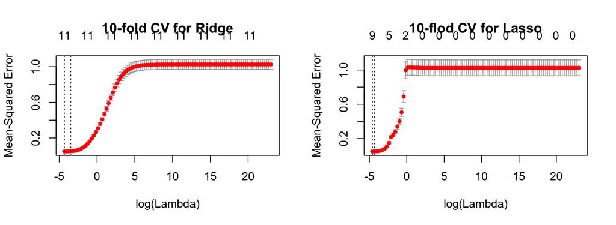

| Methods | Lambda |
| --- | --- |
| Ridge | 0.01321941 |
| Lasso | 0.01 |

## Results: PCR vs. PLSR

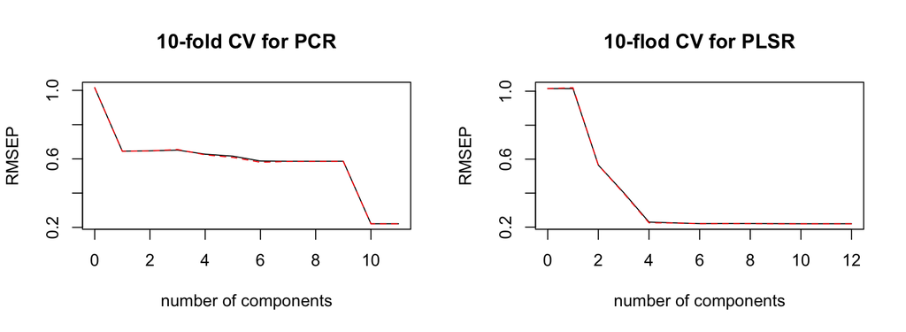

| Methods | # of Principal Components |
| --- | --- |
| PCR | 10 |
| PLSR | 4 |

## Resutls: Overall

| Method | Prediction MSE |
| --- | --- |
| OLS Regression | 0.04661927 |
| Ridge Regression | 0.04552898 |
| Lasso Regression | 0.04728975 |
| PCR | 0.04661927 |
| PLSR | 0.04889533 |

## Conclusions

In the end, we may conclude that, for this specific data set, with the randomization seed of 1, the *Ridge Regression* seems to have the best performace with respect to the mimimal Mean-square Error of the test data set.

This fact may also be due to the relatively small size of the data set. And because the relatively small number of the predictors, the Dimensional Reduction methods do not get a chance to exploit their advantages. We may expect to have improvement for problems with a larger number of predictors.